# Live Coding Assignment: Module 2

The Roper Center for Public Opinion Research Links to an external site.describes itself as "the World’s Largest Public Opinion Archive", and is an online archive of the datasets used to generate public opinion polling results dating back to 1935. It's not simply a collection of aggregate measures (such as the overall presidential approval rate over time), but it provides access to the individual responses that comprise each poll: if a poll interviewed 1000 people, we get the spreadsheet with 1000 rows. It allows us to correlate, visualize, and regress the responses to each poll question in any way we'd like.

```python
# load the three datasets
import pandas as pd
import numpy as np # probably not needed
from matplotlib import pyplot as plt
```

```python
import os
print(os.getcwd())

# print all the files in the current working directory
print(os.listdir())
```

```
c:\Users\dianam\Documents\jlab_datascience\PlayGround\UVa\ds6001\mod2\livecoding
['31119104.csv', '31119104.DTA', 'i20068.dat', 'livecodingmod2.ipynb', 'USAIPO1936-0053.csv']
```

### Gallup Poll # 1936-0053: Teachers' Oath/Government Loans for Farmers/Employers Insurance Contributions/Presidential Candidates [Roper #31087039]

```python
pd.set_option('display.max_columns',80)
```

```python
# Gallup Poll # 1936-0053: Teachers' Oath/Government Loans for Farmers/Employers Insurance Contributions/Presidential Candidates [Roper #31087039]
df_gallup = pd.read_csv('USAIPO1936-0053.csv',quotechar="\"")
print(df_gallup.shape)
df_gallup.head()
```

```
(5515, 44)
```

|  | form | state | region | female | age | class | OCCUPATION1 | OCCUPATION2 | OCCUPATION3 | black | size | education | AGE_3WAY | AGE40 | OCC8 | prof | REGION4 | EDU_RECODE | VOTE_PRO | VOTE_RETRO | PHONE_RECODE | CAR_RECODE | ballot | Q1 | Q2 | Q3 | Q4A | Q4B | Q4C | … |
| --- | --- | --- | --- | --- | --- | --- | --- | --- | --- | --- | --- | --- | --- | --- | --- | --- | --- | --- | --- | --- | --- | --- | --- | --- | --- | --- | --- | --- | --- | --- |
| 0 | NaN | Indiana | East Central | Male | NaN | Av+ | Skilled workers | NaN | NaN | NaN | Urban | NaN | NaN | NaN | Labor | Not Professional | Midwest | NaN | Landon | Hoover | NaN | NaN | 53 | Yes | Yes | Yes | Roosevelt | Roosevelt | Landon | … |
| 1 | NaN | Illinois | East Central | Male | NaN | Av+ | Skilled workers | NaN | NaN | NaN | Urban | NaN | NaN | NaN | Labor | Not Professional | Midwest | NaN | Landon | Hoover | NaN | NaN | 53 | Yes | NaN | Yes | Landon | Landon | Landon | … |
| 2 | NaN | Michigan | East Central | Male | NaN | Av | Business | NaN | NaN | NaN | Urban | NaN | NaN | NaN | Professional | Professional | Midwest | NaN | Landon | Hoover | NaN | NaN | 53 | No | No | Yes | Landon | Landon | Landon | … |
| 3 | NaN | Virginia | South and Southwest | Male | 55 yrs and over | P or P+ | Skilled workers | NaN | NaN | NaN | Urban | NaN | NaN | NaN | Labor | Not Professional | South | NaN | fdr | fdr | NaN | NaN | 53 | Yes | Yes | Yes | Roosevelt | Roosevelt | Roosevelt | … |
| 4 | NaN | Florida | South and Southwest | Male | 55 yrs and over | Av+ | Skilled workers | NaN | NaN | NaN | Small town | NaN | NaN | NaN | Labor | Not Professional | South | NaN | fdr | fdr | NaN | NaN | 53 | Yes | Yes | Yes | Roosevelt | Roosevelt | Roosevelt | … |

```python
# show a cross tab of Q3 and
pd.crosstab(df_gallup['Q3'],df_gallup['Q5A'])
```

| Q5A Q3 | Landon | Lemke | Other party | Roosevelt | Thomas |
| --- | --- | --- | --- | --- | --- |
| No | 921 | 41 | 6 | 442 | 10 |
| Yes | 820 | 109 | 6 | 2048 | 41 |

People who do not support social security, supported Landon.

People who do support social security, support FDR (Roosevelt).

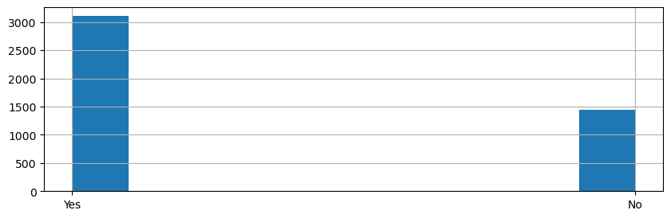

```python
# Q3 is whether they support Social Security / "Old Age Insurance"
# show a histogram of the responses
plt.figure(figsize=(10,3))
df_gallup['Q3'].hist()
```

```python
# show me the value counts for the OCCUPATION1 columns
df_gallup.OCCUPATION1.value_counts()
```

```
Skilled workers      3030
Other and None       1252
Unskilled workers     428
Professiol            382
Business              345
Unemployed             76
Name: OCCUPATION1, dtype: int64
```

[output not shown]

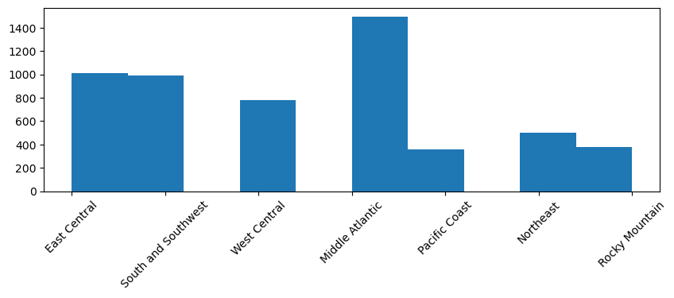

```python
# plot a histogram of histogram of the region

# set the figure size
plt.figure(figsize=(10,3))
plt.hist(df_gallup['region'])
# print the x axis labels 45 degrees
plt.xticks(rotation=45)
```

### Kaiser Family Foundation: December 2021 COVID-19 Vaccine Monitor: Early Omicron Update [Roper #31119104]

```python
# Kaiser Family Foundation: December 2021 COVID-19 Vaccine Monitor: Early Omicron Update [Roper #31119104]
#df_covid = pd.read_csv('31119104.csv')
# read the dta file
df_covid = pd.read_stata('31119104.dta')
print(df_covid.shape)
df_covid.head(3)
```

```
(1065, 79)
```

|  | id | BIDENT1 | userdata | language | INT1A | INT3A | D1 | age | AGE2 | recage | RECAGE2 | RECAGE3 | RECAGE4 | RECAGE5 | RECAGE6 | hispanic | race | racethn | nativity | RACETHN2 | VAXQ1 | VAXQ2 | VAXQ3 | VAXQ4 | VAXQ5 | VAXQ6 | VAXQ7 | coverage | agecov | … |
| --- | --- | --- | --- | --- | --- | --- | --- | --- | --- | --- | --- | --- | --- | --- | --- | --- | --- | --- | --- | --- | --- | --- | --- | --- | --- | --- | --- | --- | --- | --- |
| 0 | 00000002 | web | SSRS Probability Panel | English | NaN | NaN | NaN | 68 | NaN | 65+ | 65+ | 65+ | 60-69 | 65+ | 50+ | No | White | White, non-Hispanic | NaN | White, non-Hispanic | Somewhat worried | Yes | Yes, received a booster | NaN | Have recommended this | NaN | NaN | Covered by health insurance | NaN | … |
| 1 | 00000003 | web | SSRS Probability Panel | English | NaN | NaN | NaN | 46 | NaN | 18-64 | 30-49 | 45-54 | 40-59 | 45-64 | 18-49 | No | Black or African-American | Black, non-Hispanic | NaN | Black, non-Hispanic | Not too worried | No | NaN | NaN | Have recommended this | No, does not make me more likely | Nothing | Covered by health insurance | Insured Less than 65 | … |
| 2 | 00000004 | web | SSRS Probability Panel | English | NaN | NaN | NaN | 66 | NaN | 65+ | 65+ | 65+ | 60-69 | 65+ | 50+ | No | White | White, non-Hispanic | NaN | White, non-Hispanic | Not too worried | Yes | Yes, received a booster | NaN | Have recommended this | NaN | NaN | Covered by health insurance | NaN | … |

```python
df_covid.VAXQ1.value_counts()
```

```
Not too worried       387
Somewhat worried      379
Not at all worried    168
Very worried          129
WEB BLANK               2
Name: VAXQ1, dtype: int64
```

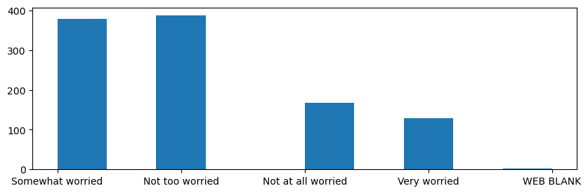

```python
# plot histogram of VAXQ1
plt.figure(figsize=(10,3))
# plot histogram of VAXQ1 color group by party
plt.hist(df_covid['VAXQ1'])
```

### USIA Poll # 2000-I20068: Economic Conditions/Government Approval/Security/Civilian Rule/International Relations/US [Roper #31086002]

```python
field_ids = range(1,37)
```

```python
# USIA Poll # 2000-I20068: Economic Conditions/Government Approval/Security/Civilian Rule/International Relations/US [Roper #31086002]
# we need our data dictionary format
# these are NOT the real widths
df_usiapoll= pd.read_fwf("i20068.dat", widths = [1,1,1,4,5,200])
df_usiapoll.head()
```

[output not shown]